# Izzo_PBIO294_FinalExam

Lisa Izzo

December 7, 2017

```r
##Set working directory
setwd("~/Vermont/Classes/Fall 2017/EcologicalModeling/EMFinalExam")
```

```r
##Load necessary libraries for all questions
library(rjags)
library(coda)
```

1. (30 points) An ecologist is interested in the intermediate disturbance hypothesis (IDH) that postulates that the highest species richness should be found at intermediate levels of disturbance. Write a likelihood function to estimate the parameters for a quadratic regression models given in Beckage and Stout 2000 (http://www.uvm.edu/~bbeckage/Manuscripts/BeckageStout.corrected.2000.jvs.pdf), but assuming a Poisson likelihood with a log link function.

Provide your i. *likelihood function and supporting R code for finding the MLE’s*, ii. a *plot of the data with the fitted line* and iii. report the *regression parameters (bo, b1, and b2)*, and iv. the value of the *negative log likelihood at the MLEs*. Note: You must write your own likelihood function and not use a built in R function or package, e.g, lm, glm, etc.

Quadratic model from Beckage and Stout 2000: *Y = B0 + B1 × Burns + B2 × Burns2 + e*

```r
##read in and check data
srDat<-read.table("http://www.uvm.edu/~bbeckage/Teaching/PBIO_294/Data/idh.csv",sep=',',header=TRUE)
head(srDat)
```

```
##   sr nFires
## 1 16      1
## 2 13      1
## 3 11      1
## 4 13      1
## 5 13      1
## 6 14      1
```

```r
str(srDat)
```

```
## 'data.frame':    300 obs. of  2 variables:
##  $ sr    : int  16 13 11 13 13 14 12 8 9 11 ...
##  $ nFires: int  1 1 1 1 1 1 1 1 1 1 ...
```

```r
##make column for squared values for use in quadratic regression
srDat$nFires2 = srDat$nFires^2
```

Part i:

```r
##Negative log likelihood function (Poisson) for the quadratic regression
nll_pois_fires2 = function(paramVec, SR, fire, fire2){
  beta0 = paramVec[1]
  beta1 = paramVec[2]
  beta2 = paramVec[3]
  lambda_sr = exp(beta0 + beta1*fire + beta2*fire2)
  nllik = -sum(dpois(x = SR,lambda = lambda_sr,log=TRUE))
  return(nllik)
}
```

```r
##Optimize negative log likelihood function to find parameter MLEs
paramVec = c(1, 1, -1) # Initial parameter values
              #based on shape of data points, we expect beta 2 to be negative

MLE_nll_fire2<-optim(par = paramVec, fn = nll_pois_fires2,
                     method = "L-BFGS-B",
                     lower = c(-Inf,-Inf,-Inf), upper = c(Inf,Inf,Inf),
                     SR = srDat$sr, fire = srDat$nFires,
                     fire2 = srDat$nFires2)

MLE_nll_fire2$par
```

```
## [1]  2.05567418  0.44364855 -0.04578292
```

Part ii:

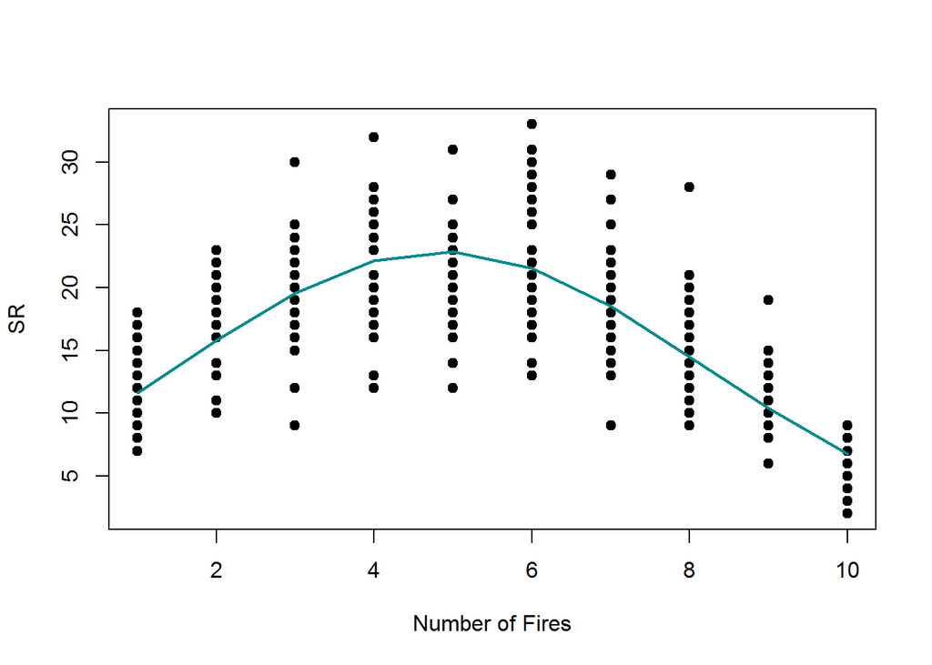

```r
##Plot data points and fitted regression line based on MLE
predict_fires = srDat$nFires[order(srDat$nFires)]
plot(srDat$sr ~ srDat$nFires, ylab = "SR", xlab = "Number of Fires", pch = 19)

lines(predict_fires, exp(MLE_nll_fire2$par[1] +
                           MLE_nll_fire2$par[2]*predict_fires +
                           MLE_nll_fire2$par[3]*predict_fires^2),
                            col='darkcyan',lwd=2)
```

Part iii:

```r
beta0_MLE = MLE_nll_fire2$par[1]
beta1_MLE = MLE_nll_fire2$par[2]
beta2_MLE = MLE_nll_fire2$par[3]

print(beta0_MLE)
```

```
## [1] 2.055674
```

```r
print(beta1_MLE)
```

```
## [1] 0.4436485
```

```r
print(beta2_MLE)
```

```
## [1] -0.04578292
```

The parameter estimates using the MLE method are: Beta0 = 2.055 Beta1 = 0.444 Beta2 = -0.046

Part iv:

```r
MLE_nll_fire2$value
```

```
## [1] 848.0172
```

2. (30 points) Repeat exercise 1 except now fitting the model using either Rstan or Rjags. You must write your own Stan/JAGS model, meaning that you can not use one of the Stan helper libraries such as the brms or rstanarm libraries. Provide your i. *Stan/JAGS model code and supporting R code for running the Stan/JAGS model*, ii. report the *2.5%, 50%, and 97.5% percentiles for the regression parameters (bo, b1, and b2)*, iii. *plot the posterior distributions for each of these parameters* and iv. *assess the convergence of your chains using the Gelman-Rubin statistic.*

Part i:

```r
##specify JAGS model

Fire_Quadratic_JAGSmod <- "
 model {
  for (i in 1:N){
    SR[i] ~ dpois(lambda[i])
    log(lambda[i]) <- beta0 + beta1 * Fire[i] + beta2 * pow(Fire[i], 2)
  }
  #priors
  beta0 ~ dnorm(0, 0.001)
  beta1 ~ dnorm(0, 0.001)
  beta2 ~ dnorm(0, 0.001)
}
"

writeLines(Fire_Quadratic_JAGSmod, con='Fire_Quadratic_JAGSmod.txt')
```

```r
##put data into list to be used in JAGS

srDatList = list(SR = srDat$sr,
                 Fire = srDat$nFires,
                 N = nrow(srDat))

##set chains, burn in, and iterations
nchains = 4
nburnin = 200
niter = 20000

##run JAGS model

Fires_JAGS = jags.model('Fire_Quadratic_JAGSmod.txt',
                        data = srDatList,
                        n.chains = nchains,
                        n.adapt = 100)
update(Fires_JAGS, nburnin)
jags.samples(Fires_JAGS, c("beta0", "beta1", "beta2"), niter)
```

```
## $beta0
## mcarray:
## [1] 2.066228
##
## Marginalizing over: iteration(20000),chain(4)
##
## $beta1
## mcarray:
## [1] 0.4388819
##
## Marginalizing over: iteration(20000),chain(4)
##
## $beta2
## mcarray:
## [1] -0.04537699
##
## Marginalizing over: iteration(20000),chain(4)
```

Part ii:

```r
##sample JAGS model using coda package to summarize model results
Fires_coda = coda.samples(Fires_JAGS, c("beta0", "beta1", "beta2"), niter)
```

The parameter estimates and the 2.5%, 50%, and 97.5% percentiles are:

```r
##summarize parameter estimates
summary(Fires_coda)
```

```
##
## Iterations = 20301:40300
## Thinning interval = 1
## Number of chains = 4
## Sample size per chain = 20000
##
## 1. Empirical mean and standard deviation for each variable,
##    plus standard error of the mean:
##
##           Mean      SD  Naive SE Time-series SE
## beta0  2.05950 0.05907 2.088e-04      0.0025616
## beta1  0.44171 0.02424 8.572e-05      0.0012123
## beta2 -0.04562 0.00222 7.850e-06      0.0001028
##
## 2. Quantiles for each variable:
##
##           2.5%      25%      50%     75%    97.5%
## beta0  1.94248  2.01997  2.05982  2.0997  2.17448
## beta1  0.39439  0.42519  0.44148  0.4582  0.48945
## beta2 -0.04995 -0.04713 -0.04561 -0.0441 -0.04127
```

Part iii:

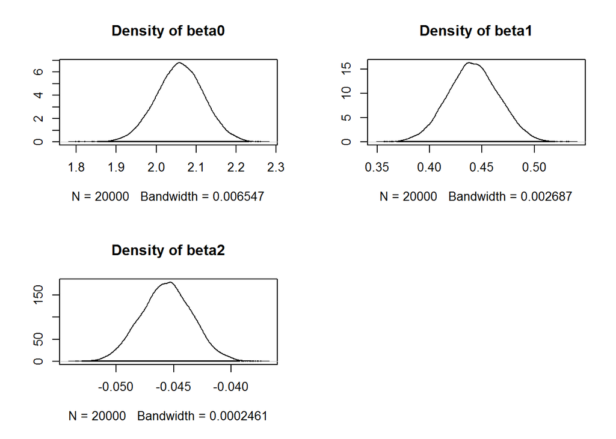

```r
##plot posterior distributions of each parameter
plot(Fires_coda, trace = FALSE)
```

Part iv:

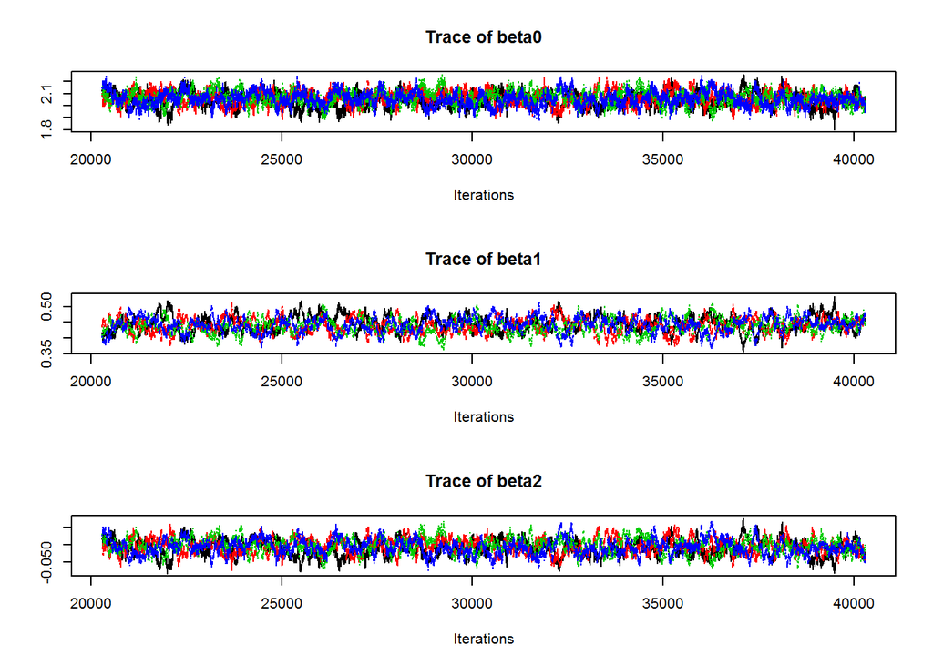

```r
##check traceplots for any visual signs of lack of convergence
par(mfrow = c(3,1))
traceplot(Fires_coda)
```

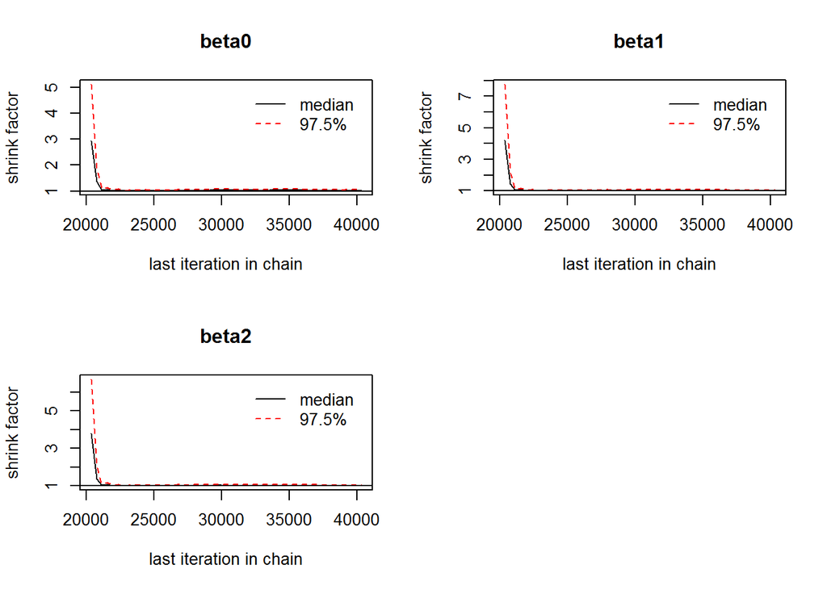

```r
gelman.plot(Fires_coda)
```

```r
gelman.diag(Fires_coda)
```

```
## Potential scale reduction factors:
##
##       Point est. Upper C.I.
## beta0       1.02       1.05
## beta1       1.02       1.06
## beta2       1.02       1.05
##
## Multivariate psrf
##
## 1.02
```

The Gelman-Rubin statistic is very close to 1 for all paramters, indicating that the chains have converged.

Fit this model using either Rstan or Rjags. You must write your own Stan/JAGS model, meaning that you can not use one of the Stan helper libraries such as the brms or rstanarm libraries. Provide your i. *Stan/JAGS model code and supporting R code for running the Stan/JAGS model*, ii. report the *2.5%, 50%, and 97.5% percentiles for the regression parameters (b1, b1, b2, b3, and b4)*, iii. *plot the posterior distributions for each of these parameters* and iv. *assess the convergence of your chains using the Gelman-Rubin statistic.*

```r
##read in and check data
seeds<-read.table("http://www.uvm.edu/~bbeckage/Teaching/PBIO_294/Data/seeds.csv",sep=',',header=TRUE)
head(seeds)
```

```
##   seedLost     mass gap
## 1        1 4.479734   1
## 2        1 6.675165   1
## 3        1 1.654855   1
## 4        1 8.239288   1
## 5        1 2.503247   1
## 6        1 1.384419   1
```

```r
str(seeds)
```

```
## 'data.frame':    1000 obs. of  3 variables:
##  $ seedLost: int  1 1 1 1 1 1 1 1 1 1 ...
##  $ mass    : num  4.48 6.68 1.65 8.24 2.5 ...
##  $ gap     : int  1 1 1 1 1 1 1 1 1 1 ...
```

```r
##add squared column for quadratic model
seeds$mass2 = seeds$mass^2
```

Part i:

```r
##specify JAGS model

Seeds_HM_JAGSmod <- "
 model {

  for (i in 1:N){
    SeedLost[i] ~ dbern(theta[i])
    logit(theta[i]) <- beta0[i] + beta1 * Gap[i]
  }

  for (i in 1:N){
    beta0[i] ~ dgamma(shape[i], rate[i])
    log(mu[i]) = beta2 + beta3*mass[i] - beta4*mass2[i]
    mu2[i] = pow(mu[i], 2)
    shape[i] = mu2[i]/sd2[i]
    rate[i] = mu[i]/sd2[i]
    sd2[i] ~ dgamma(0.001, 0.001)
  }

#priors
  beta1 ~ dnorm(0, 0.001)
  beta2 ~ dnorm(0, 0.001)
  beta3 ~ dnorm(0, 0.001)
  beta4 ~ dnorm(0, 0.001)
}
"

writeLines(Seeds_HM_JAGSmod, con='Seeds_HM_JAGSmod.txt')
```

```r
##put data into list to be used in Bayesian model

seedsDatList = list(SeedLost = seeds$seedLost,
                    Gap = seeds$gap,
                    mass = seeds$mass,
                    mass2 = seeds$mass2,
                    N = nrow(seeds))

##set chains, burn in, and iterations
nchains = 2
nburnin = 1000
niter = 25000

##run JAGS model

Seeds_HM_JAGS = jags.model('Seeds_HM_JAGSmod.txt',
                           data = seedsDatList,
                           n.chains = nchains,
                           n.adapt = 1000)
update(Seeds_HM_JAGS, nburnin)
jags.samples(Seeds_HM_JAGS, c("beta1", "beta2", "beta3", "beta4"), niter, thin = 10)
```

```
## $beta1
## mcarray:
## [1] 1.877816
##
## Marginalizing over: iteration(2500),chain(2)
##
## $beta2
## mcarray:
## [1] 0.01907771
##
## Marginalizing over: iteration(2500),chain(2)
##
## $beta3
## mcarray:
## [1] 0.02790937
##
## Marginalizing over: iteration(2500),chain(2)
##
## $beta4
## mcarray:
## [1] 0.00161875
##
## Marginalizing over: iteration(2500),chain(2)
```

Part ii:

```r
##sample JAGS model using coda package to summarize model results
Seeds_coda = coda.samples(Seeds_HM_JAGS, c("beta1", "beta2", "beta3", "beta4"), niter, thin = 10)
```

The parameter estimates and the 2.5%, 50%, and 97.5% percentiles are:

```r
##summarize parameter estimates
summary(Seeds_coda)
```

```
##
## Iterations = 27010:52000
## Thinning interval = 10
## Number of chains = 2
## Sample size per chain = 2500
##
## 1. Empirical mean and standard deviation for each variable,
##    plus standard error of the mean:
##
##           Mean       SD  Naive SE Time-series SE
## beta1 1.881204 0.202830 2.868e-03      2.847e-03
## beta2 0.019078 0.012767 1.805e-04      2.456e-08
## beta3 0.027909 0.008617 1.219e-04      0.000e+00
## beta4 0.001619 0.000305 4.313e-06      0.000e+00
##
## 2. Quantiles for each variable:
##
##           2.5%      25%      50%      75%    97.5%
## beta1 1.488295 1.742812 1.877267 2.013315 2.297346
## beta2 0.006312 0.006312 0.019078 0.031843 0.031843
## beta3 0.019293 0.019293 0.027909 0.036526 0.036526
## beta4 0.001314 0.001314 0.001619 0.001924 0.001924
```

Part iii:

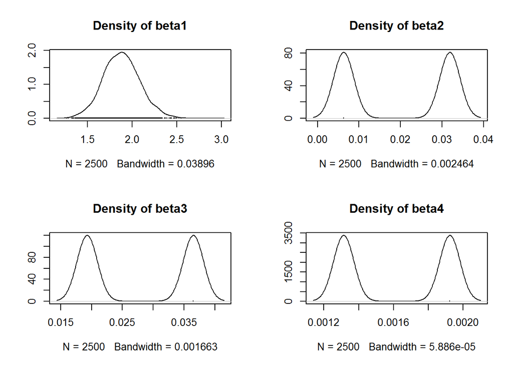

```r
##plot posterior distributions of each parameter
plot(Seeds_coda, trace=FALSE)
```

Part iv:

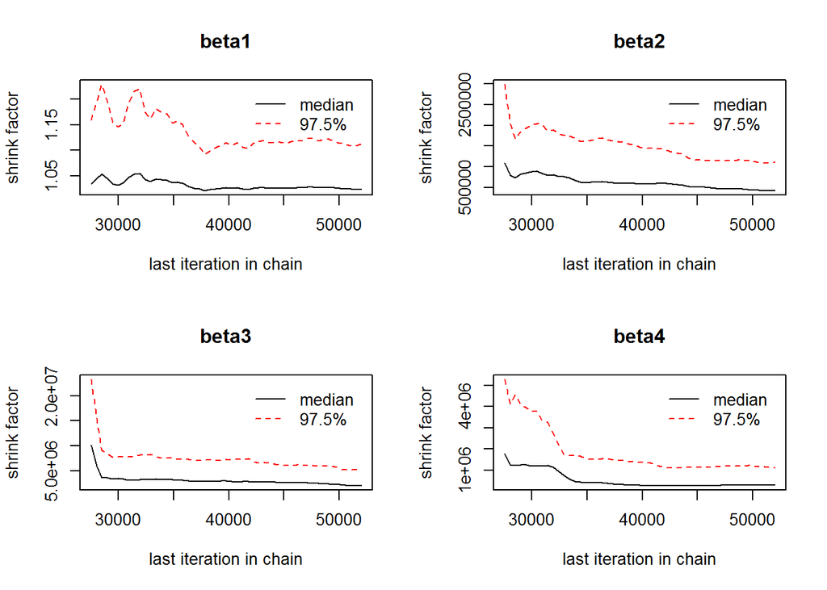

```r
##check traceplots for any visual signs of lack of convergence
#par(mfrow = c(4,1))
#traceplot(Seeds_coda)


gelman.plot(Seeds_coda)
```

```r
gelman.diag(Seeds_coda)
```

```
## Potential scale reduction factors:
##
##       Point est. Upper C.I.
## beta1   1.02e+00   1.11e+00
## beta2   4.24e+05   1.10e+06
## beta3   1.98e+06   5.09e+06
## beta4   2.96e+05   1.11e+06
##
## Multivariate psrf
##
## 1331978
```

While the chains for the beta 1 parameter have converged, the beta 2, beta 3, and beta 4 parameters have not converged. The chains for these parameters are not mixing well, so it would take a large number of iterations for the values to converge.